# NYC FHVHV

[figure not shown]

This project analyzes New York City for-hire vehicle (FHV) trip data for May 2022 to uncover insights into trip patterns and compare the usage of different ride-sharing providers, primarily Uber and Lyft. The analysis involves extensive data cleaning, exploratory data analysis (EDA), and the creation of various visualizations to present the findings.

## Analysis Summary

The analysis begins by loading and cleaning a large dataset of over 18 million trip records. Key data cleaning steps include:

- **Handling Missing Values:** A significant percentage of missing values were found in the `originating_base_num` and `on_scene_datetime` columns, which were entirely associated with Lyft. These missing values were handled by dropping the corresponding rows.
- **Removing Duplicates:** Duplicate trip records were identified and removed from the dataset.
- **Data Transformation:** A `provider` column was added to distinguish between Uber and Lyft trips. The dataset was also merged with taxi zone information to enable geospatial analysis.

Following data cleaning, EDA was performed to explore the trip data, revealing several key insights:

- **Provider Market Share:** Uber dominates the market, accounting for approximately 99.95% of the trips in the cleaned dataset.
- **Trip Characteristics:** The analysis identified the busiest pickup locations and examined the distribution of trip distances, durations, and congestion surcharges. It also flagged and investigated data inaccuracies, such as trips with unrealistic mileage.
- **Temporal Patterns:** Trip volumes were analyzed on a daily and hourly basis, as well as by the day of the week, to identify peak and off-peak travel times.

## Model

Various models where tested including the linear regression model, random forest and XGBoost model

The results are as follows

| Model | R² |
| --- | --- |
| XGBoost Regressor | 0.820476233959198 |
| Linear Regression | 0.6713597485005395 |
| Random Forest | 0.9427381187867035 |

## Visualizations

Several visualizations were created to illustrate the findings of the analysis, including:

- **Distribution of Trips by Provider:** A bar chart highlights the significant disparity in trip volume between Uber and Lyft.

[figure not shown]

- **Trip Distance and Duration Analysis:** Bar charts show the distribution of trip distances and durations for each provider, and a scatter plot explores the relationship between these two variables.
- **Trips Over Time:** Line charts and count plots visualize the number of trips per day, by the hour, and by the day of the week, offering a clear view of temporal demand patterns.
- **Top 10 Routes:** A line chart displays the hourly trip counts for the ten most popular routes, providing insights into high-traffic corridors.
- **Geospatial Heatmap:** A choropleth map illustrates the number of pickups per taxi zone, visually representing the geographic distribution of trip origins across the city.

```python
# This Python 3 environment comes with many helpful analytics libraries installed
  # It is defined by the kaggle/python Docker image: https://github.com/kaggle/docker-python
  # For example, here's several helpful packages to load

  import numpy as np # linear algebra
  import pandas as pd # data processing, CSV file I/O (e.g. pd.read_csv)

  # Input data files are available in the read-only "../input/" directory
  # For example, running this (by clicking run or pressing Shift+Enter) will list all files under the input directory


  # You can write up to 20GB to the current directory (/kaggle/working/) that gets preserved as output when you create a version using "Save & Run All"
  # You can also write temporary files to /kaggle/temp/, but they won't be saved outside of the current session
```

```python
import os
  import shutil

  # Path to your kaggle.json (adjust if stored somewhere else)
  kaggle_json = "kaggle.json"

  # Create .kaggle folder
  os.makedirs(os.path.expanduser("~/.kaggle"), exist_ok=True)

  # Copy kaggle.json into place
  shutil.copy(kaggle_json, os.path.expanduser("~/.kaggle/kaggle.json"))

  # Fix permissions (important for Linux/Mac)
  os.chmod(os.path.expanduser("~/.kaggle/kaggle.json"), 0o600)
```

```python
# Example: Wine Reviews dataset
  !kaggle datasets download -d jeffsinsel/nyc-fhvhv-data -p ./data
```

[output not shown]

```python
!kaggle datasets download -d mxruedag/tlc-nyc-taxi-zones -p ./data
```

```python
import zipfile

  with zipfile.ZipFile("./data/tlc-nyc-taxi-zones.zip", 'r') as zip_ref:
	  zip_ref.extractall("./data/tlc-nyc-taxi-zones")
```

```python
import zipfile

  with zipfile.ZipFile("./data/archive.zip", 'r') as zip_ref:
	  zip_ref.extractall("./data/archive")
```

```python
months = ['2022-05']
  PATH = './data/archive/'
  list_data = [f for f in os.listdir(PATH) if any(m in f for m in months)]
  list_data.sort()
  print(list_data)
```

```
  ['fhvhv_tripdata_2022-05.parquet']
```

```python
path_files=[]

  for file in list_data:
	  path_files.append(pd.read_parquet(PATH+file))

  df=pd.concat(path_files,ignore_index=True)
```

```python
import numpy as np
```

```python
len(df)
  print(df.shape)
```

```
  (18157335, 24)
```

```python
df.describe()
```

|  | request_datetime | on_scene_datetime | pickup_datetime | dropoff_datetime | PULocationID | DOLocationID | trip_miles | trip_time | base_passenger_fare | tolls | bcf | sales_tax | congestion_surcharge | airport_fee | tips | driver_pay |
| --- | --- | --- | --- | --- | --- | --- | --- | --- | --- | --- | --- | --- | --- | --- | --- | --- |
| count | 18157335 | 13331636 | 18157335 | 18157335 | 1.815734e+07 | 1.815734e+07 | 1.815734e+07 | 1.815734e+07 | 1.815734e+07 | 1.815734e+07 | 1.815734e+07 | 1.815734e+07 | 1.815734e+07 | 1.815734e+07 | 1.815734e+07 | 1.815734e+07 |
| mean | 2022-05-16 10:47:49.414954 | 2022-05-16 09:53:21.594984 | 2022-05-16 10:53:37.462248 | 2022-05-16 11:13:42.581826 | 1.392221e+02 | 1.429745e+02 | 5.168193e+00 | 1.205217e+03 | 2.558900e+01 | 1.182228e+00 | 8.075211e-01 | 2.167914e+00 | 1.162459e+00 | 2.190424e-01 | 1.166654e+00 | 2.016882e+01 |
| min | 2022-04-30 23:17:39 | 2022-04-30 23:50:58 | 2022-05-01 00:00:00 | 2022-05-01 00:02:34 | 1.000000e+00 | 1.000000e+00 | 0.000000e+00 | 0.000000e+00 | -3.252800e+02 | 0.000000e+00 | 0.000000e+00 | 0.000000e+00 | 0.000000e+00 | 0.000000e+00 | 0.000000e+00 | -1.244800e+02 |
| 25% | 2022-05-08 14:42:23.500000 | 2022-05-08 13:42:53 | 2022-05-08 14:49:23 | 2022-05-08 15:10:48 | 7.600000e+01 | 7.600000e+01 | 1.650000e+00 | 6.110000e+02 | 1.242000e+01 | 0.000000e+00 | 3.700000e-01 | 1.030000e+00 | 0.000000e+00 | 0.000000e+00 | 0.000000e+00 | 9.680000e+00 |
| 50% | 2022-05-16 08:14:56 | 2022-05-16 08:32:25.500000 | 2022-05-16 08:21:06 | 2022-05-16 08:42:40 | 1.400000e+02 | 1.420000e+02 | 3.110000e+00 | 9.740000e+02 | 1.978000e+01 | 0.000000e+00 | 6.000000e-01 | 1.680000e+00 | 0.000000e+00 | 0.000000e+00 | 0.000000e+00 | 1.575000e+01 |
| 75% | 2022-05-23 19:36:57 | 2022-05-23 17:43:36 | 2022-05-23 19:41:09 | 2022-05-23 19:59:24 | 2.110000e+02 | 2.190000e+02 | 6.450000e+00 | 1.533000e+03 | 3.157000e+01 | 0.000000e+00 | 9.900000e-01 | 2.740000e+00 | 2.750000e+00 | 0.000000e+00 | 0.000000e+00 | 2.527000e+01 |
| max | 2022-06-01 00:10:00 | 2022-05-31 23:59:59 | 2022-05-31 23:59:59 | 2022-06-01 04:26:03 | 2.650000e+02 | 2.650000e+02 | 4.717300e+02 | 6.827100e+04 | 2.493860e+03 | 1.200000e+02 | 8.395000e+01 | 2.283800e+02 | 1.100000e+01 | 6.900000e+00 | 1.942200e+02 | 1.838600e+03 |
| std | NaN | NaN | NaN | NaN | 7.484273e+01 | 7.788400e+01 | 5.977043e+00 | 8.801463e+02 | 2.105190e+01 | 3.935689e+00 | 7.046468e-01 | 1.757625e+00 | 1.368854e+00 | 7.118799e-01 | 3.234773e+00 | 1.612831e+01 |

```python
df.isnull().values.any()
```

```
np.True_
```

```python
df.isnull().sum()
```

```
  hvfhs_license_num             0
  dispatching_base_num          0
  originating_base_num    4825699
  request_datetime              0
  on_scene_datetime       4825699
  pickup_datetime               0
  dropoff_datetime              0
  PULocationID                  0
  DOLocationID                  0
  trip_miles                    0
  trip_time                     0
  base_passenger_fare           0
  tolls                         0
  bcf                           0
  sales_tax                     0
  congestion_surcharge          0
  airport_fee                   0
  tips                          0
  driver_pay                    0
  shared_request_flag           0
  shared_match_flag             0
  access_a_ride_flag            0
  wav_request_flag              0
  wav_match_flag                0
  dtype: int64
```

```python
missing_ratio = df.isnull().sum() / len(df) # % missing
  print(missing_ratio)
```

```
  hvfhs_license_num       0.000000
  dispatching_base_num    0.000000
  originating_base_num    0.265771
  request_datetime        0.000000
  on_scene_datetime       0.265771
  pickup_datetime         0.000000
  dropoff_datetime        0.000000
  PULocationID            0.000000
  DOLocationID            0.000000
  trip_miles              0.000000
  trip_time               0.000000
  base_passenger_fare     0.000000
  tolls                   0.000000
  bcf                     0.000000
  sales_tax               0.000000
  congestion_surcharge    0.000000
  airport_fee             0.000000
  tips                    0.000000
  driver_pay              0.000000
  shared_request_flag     0.000000
  shared_match_flag       0.000000
  access_a_ride_flag      0.000000
  wav_request_flag        0.000000
  wav_match_flag          0.000000
  dtype: float64
```

```python
provider_map = {
	  "HV0002": "Juno",
	  "HV0003": "Uber",
	  "HV0004": "Via",
	  "HV0005": "Lyft"
  }

  df["provider"] = df["hvfhs_license_num"].map(provider_map)
```

```python
# Count missing values per provider
  df.groupby("provider")[["on_scene_datetime", "originating_base_num"]].apply(
	  lambda g: g.isna().sum()
  )
```

| provider | on_scene_datetime | originating_base_num |
| --- | --- | --- |
| Lyft | 4825699 | 4825699 |
| Uber | 0 | 0 |

```python
df["originating_base_num"] = df["originating_base_num"].fillna("UNKNOWN")
```

```python
print(df["hvfhs_license_num"].value_counts())
```

```
  hvfhs_license_num
  HV0003    13325434
  HV0005     4831901
  Name: count, dtype: int64
```

```python
df.duplicated().sum()
  df.drop_duplicates(inplace=True)
```

```python
df = df.dropna()
```

```python
print(df["hvfhs_license_num"].value_counts())
```

```
  hvfhs_license_num
  HV0003    13323562
  HV0005        6202
  Name: count, dtype: int64
```

```python
print(df.shape)
```

```
  (13329764, 25)
```

```python
missing_ratio = df.isnull().sum() / len(df) # % missing
  print(missing_ratio)
```

```
  hvfhs_license_num       0.0
  dispatching_base_num    0.0
  originating_base_num    0.0
  request_datetime        0.0
  on_scene_datetime       0.0
  pickup_datetime         0.0
  dropoff_datetime        0.0
  PULocationID            0.0
  DOLocationID            0.0
  trip_miles              0.0
  trip_time               0.0
  base_passenger_fare     0.0
  tolls                   0.0
  bcf                     0.0
  sales_tax               0.0
  congestion_surcharge    0.0
  airport_fee             0.0
  tips                    0.0
  driver_pay              0.0
  shared_request_flag     0.0
  shared_match_flag       0.0
  access_a_ride_flag      0.0
  wav_request_flag        0.0
  wav_match_flag          0.0
  provider                0.0
  dtype: float64
```

```python
print(df.shape)
```

```
  (13329764, 25)
```

```python
busiest_pu = df.groupby("PULocationID").size().sort_values(ascending=False).head(10)
  print(busiest_pu)
```

```
  PULocationID
  138    258507
  132    249771
  79     201120
  230    197892
  161    187678
  231    175556
  68     173554
  246    160498
  234    159962
  61     159742
  dtype: int64
```

```python
df["hvfhs_license_num"].value_counts(normalize=True) * 100
```

```
  hvfhs_license_num
  HV0003    99.953473
  HV0005     0.046527
  Name: proportion, dtype: float64
```

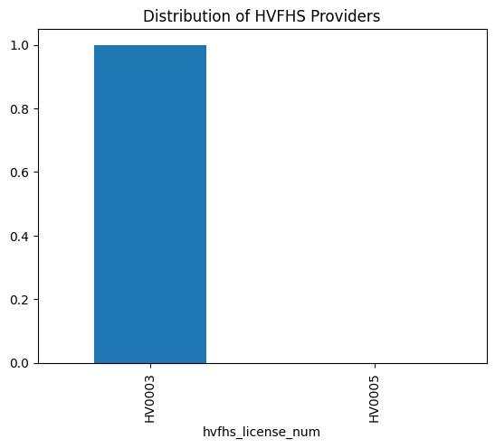

```python
df["hvfhs_license_num"].value_counts(normalize=True).plot(
	  kind="bar",
	  title="Distribution of HVFHS Providers"
  )
```

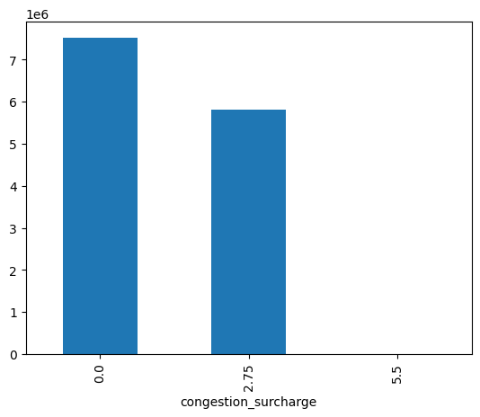

```python
df.groupby("congestion_surcharge").size().plot(kind="bar")
```

```python
inacurate_dates = df[df["dropoff_datetime"] < df["pickup_datetime"]]
  print(len(inacurate_dates))
```

```
  0
```

```python
unrealistic_values = df[(df["trip_miles"] > 100)]
  print(len(unrealistic_values))
```

```
  1542
```

```python
import matplotlib.pyplot as plt
```

```
  trip_miles_bin     0–100  100–200  200–300  300–400  400–500
  provider
  Lyft                6202        0        0        0        0
  Uber            13322019     1350      173       14        6
```

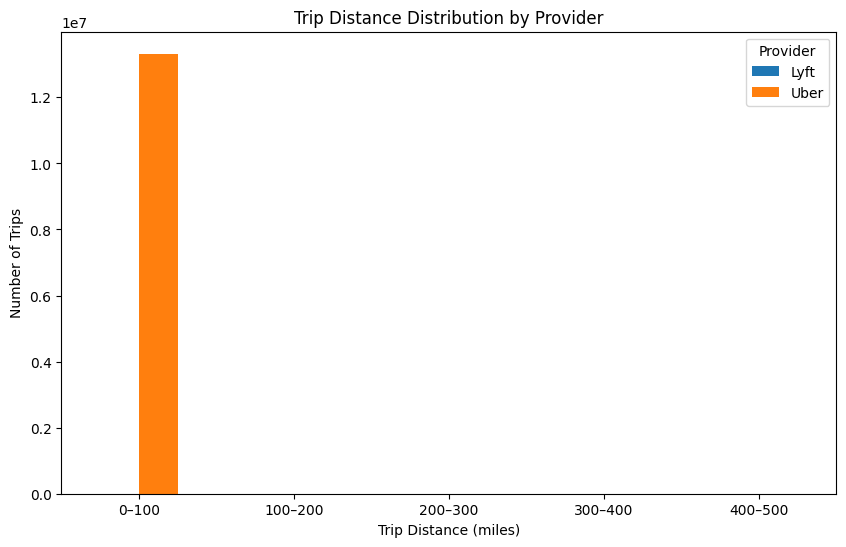

```python
bins = [0, 100, 200, 300, 400, 500]
  labels = ["0–100", "100–200", "200–300", "300–400", "400–500"]

  # Create binned column
  df["trip_miles_bin"] = pd.cut(df["trip_miles"], bins=bins, labels=labels, right=False)

  trip_dist_summary = (
	  df.groupby(["provider", "trip_miles_bin"])
	  .size()
	  .unstack(fill_value=0)
  )

  print(trip_dist_summary)


  trip_dist_summary.T.plot(kind="bar", figsize=(10,6))

  plt.title("Trip Distance Distribution by Provider")
  plt.xlabel("Trip Distance (miles)")
  plt.ylabel("Number of Trips")
  plt.xticks(rotation=0)
  plt.legend(title="Provider")
  plt.show()
```

```python
b_trip_time = df[(df["trip_time"] > 14400)]
  len(b_trip_time)
```

```
266
```

```
  trip_time_bin_hr      0–1h    1–2h  2–3h  3–4h  4–5h  5–6h  6–7h  7–8h
  provider
  Lyft                  5971     223     8     0     0     0     0     0
  Uber              13006374  307954  8159   809   164    53    22    16
```

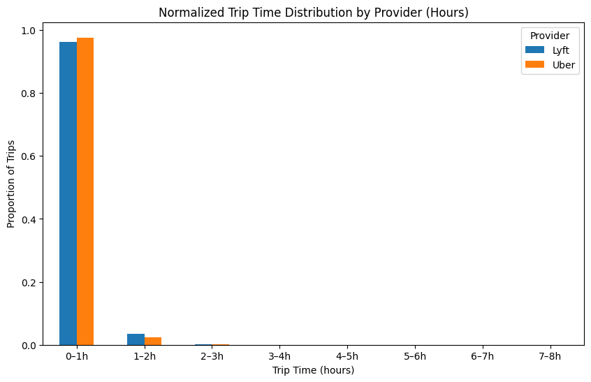

```python
# Create a new column in hours
  df["trip_time_hr"] = df["trip_time"] / 3600  # 3600 seconds = 1 hour

  bins = [0, 1, 2, 3, 4, 5, 6, 7, 8]
  labels = ["0–1h", "1–2h", "2–3h", "3–4h", "4–5h", "5–6h", "6–7h", "7–8h"]

  # Create binned column
  df["trip_time_bin_hr"] = pd.cut(df["trip_time_hr"], bins=bins, labels=labels, right=False)

  trip_time_summary_hr = (
	  df.groupby(["provider", "trip_time_bin_hr"])
	  .size()
	  .unstack(fill_value=0)
  )

  print(trip_time_summary_hr)

  trip_time_normalized_hr = trip_time_summary_hr.div(trip_time_summary_hr.sum(axis=1), axis=0)


  trip_time_normalized_hr.T.plot(kind="bar", figsize=(10,6))

  plt.title("Normalized Trip Time Distribution by Provider (Hours)")
  plt.xlabel("Trip Time (hours)")
  plt.ylabel("Proportion of Trips")
  plt.xticks(rotation=0)
  plt.legend(title="Provider")
  plt.show()
```

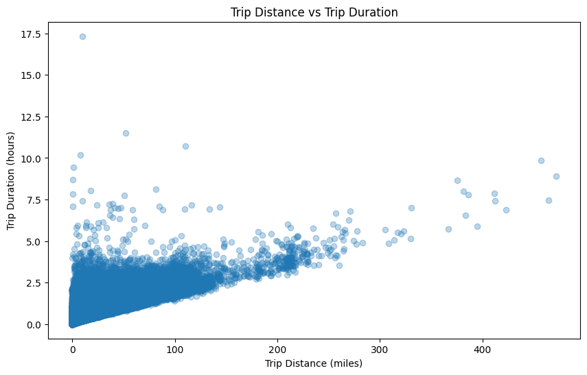

```python
import matplotlib.pyplot as plt

  plt.figure(figsize=(10,6))
  plt.scatter(df["trip_miles"], df["trip_time_hr"], alpha=0.3)  # using hours for y-axis
  plt.xlabel("Trip Distance (miles)")
  plt.ylabel("Trip Duration (hours)")
  plt.title("Trip Distance vs Trip Duration")
  plt.show()
```

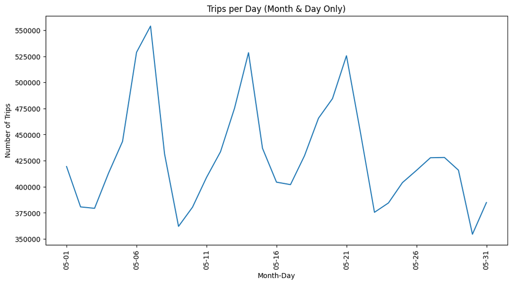

```python
# Extract month-day as "MM-DD"
  df["pickup_month_day"] = df["pickup_datetime"].dt.strftime("%m-%d")

  df.groupby("pickup_month_day").size().plot(figsize=(12,6))

  plt.xlabel("Month-Day")
  plt.ylabel("Number of Trips")
  plt.title("Trips per Day (Month & Day Only)")
  plt.xticks(rotation=90)  # rotate labels to fit
  plt.show()
```

```python
import seaborn as sns
```

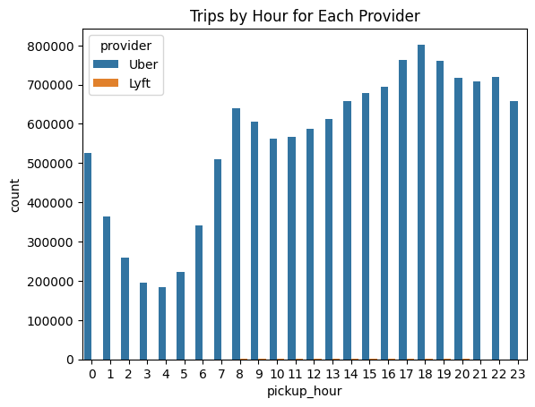

```python
df["pickup_hour"] = df["pickup_datetime"].dt.hour
  sns.countplot(data=df, x="pickup_hour", hue="provider")
  plt.title("Trips by Hour for Each Provider")
  plt.show()
```

```python
df.groupby("provider")[["shared_request_flag", "wav_match_flag"]].apply(lambda x: (x=="Y").mean())
```

| provider | shared_request_flag | wav_match_flag |
| --- | --- | --- |
| Lyft | 0.0 | 1.000000 |
| Uber | 0.0 | 0.061347 |

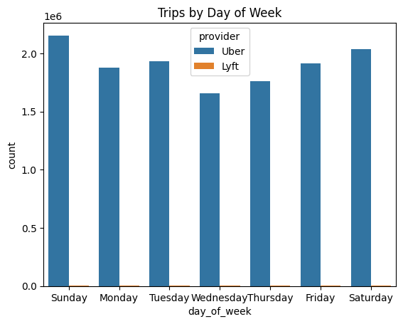

```python
df["day_of_week"] = df["pickup_datetime"].dt.day_name()
  sns.countplot(data=df, x="day_of_week", hue="provider")
  plt.title("Trips by Day of Week")
  plt.show()
```

```python
df["route"] = df["PULocationID"].astype(str) + " → " + df["DOLocationID"].astype(str)

  df["pickup_hour"] = df["pickup_datetime"].dt.hour
```

```python
top_routes = df["route"].value_counts().head(10).index.tolist()
  df_top_routes = df[df["route"].isin(top_routes)]
```

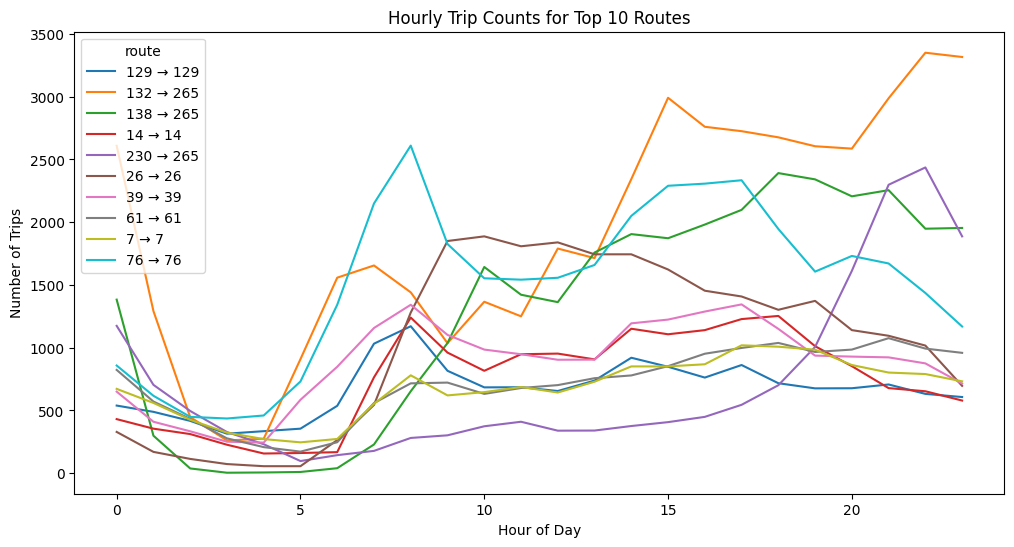

```python
route_hourly = df_top_routes.groupby(["route", "pickup_hour"]).size().unstack(fill_value=0)

  # Plot
  route_hourly.T.plot(figsize=(12,6))
  plt.title("Hourly Trip Counts for Top 10 Routes")
  plt.xlabel("Hour of Day")
  plt.ylabel("Number of Trips")
  plt.show()
```

```python
zones = pd.read_csv('./data/tlc-nyc-taxi-zones/taxi_zones.csv')
  zones.head()
```

|  | OBJECTID | Shape_Leng | the_geom | Shape_Area | zone | LocationID | borough |
| --- | --- | --- | --- | --- | --- | --- | --- |
| 0 | 1 | 0.116357 | MULTIPOLYGON (((-74.18445299999996 40.69499599... | 0.000782 | Newark Airport | 1 | EWR |
| 1 | 2 | 0.433470 | MULTIPOLYGON (((-73.82337597260663 40.63898704... | 0.004866 | Jamaica Bay | 2 | Queens |
| 2 | 3 | 0.084341 | MULTIPOLYGON (((-73.84792614099985 40.87134223... | 0.000314 | Allerton/Pelham Gardens | 3 | Bronx |
| 3 | 4 | 0.043567 | MULTIPOLYGON (((-73.97177410965318 40.72582128... | 0.000112 | Alphabet City | 4 | Manhattan |
| 4 | 5 | 0.092146 | MULTIPOLYGON (((-74.17421738099989 40.56256808... | 0.000498 | Arden Heights | 5 | Staten Island |

```python
# Pickup zone
  df = df.merge(zones[['LocationID', 'zone']],
				left_on='PULocationID', right_on='LocationID',
				how='left')
  df.rename(columns={'zone':'PU_Zone'}, inplace=True)
  df.drop(columns='LocationID', inplace=True)

  # Drop-off zone
  df = df.merge(zones[['LocationID', 'zone']],
				left_on='DOLocationID', right_on='LocationID',
				how='left')
  df.rename(columns={'zone':'DO_Zone'}, inplace=True)
  df.drop(columns='LocationID', inplace=True)

  # Create readable route
  df['route'] = df['PU_Zone'] + " → " + df['DO_Zone']
```

```python
import geopandas as gpd
```

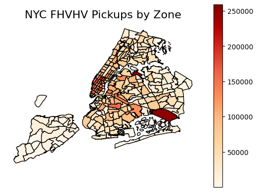

```python
zones_gdf = gpd.GeoDataFrame(zones, geometry=gpd.GeoSeries.from_wkt(zones["the_geom"]))

  # Count pickups per zone
  pickup_counts = df.groupby("PULocationID").size().reset_index(name="pickup_count")

  # Merge counts with geometry
  zones_gdf = zones_gdf.merge(pickup_counts, left_on="LocationID", right_on="PULocationID", how="left")

  # Plot heatmap
  plt.figure(figsize=(12,10))
  zones_gdf.plot(column="pickup_count", cmap="OrRd", legend=True, edgecolor="black")
  plt.title("NYC FHVHV Pickups by Zone", fontsize=16)
  plt.axis("off")
  plt.show()
```

```python
from shapely import wkt

  zones["geometry"] = zones["the_geom"].apply(wkt.loads)
  zones_gdf = gpd.GeoDataFrame(zones, geometry="geometry", crs="EPSG:4326")

  zones_gdf["centroid"] = zones_gdf.geometry.centroid

  pickup_counts = df.groupby("PULocationID").size().reset_index(name="pickup_count")

  zones_with_counts = zones_gdf.merge(pickup_counts, left_on="LocationID", right_on="PULocationID", how="left")
  zones_with_counts["pickup_count"] = zones_with_counts["pickup_count"].fillna(0)

  import folium
  from folium.plugins import HeatMap

  # Prepare data for heatmap (lat, lon, intensity)
  heat_data = [
	  [row["centroid"].y, row["centroid"].x, row["pickup_count"]]
	  for _, row in zones_with_counts.iterrows()
	  if row["pickup_count"] > 0
  ]

  # Create map
  m = folium.Map(location=[40.7128, -74.0060], zoom_start=11, tiles="cartodbpositron")
  HeatMap(heat_data, radius=12, blur=8, max_zoom=1).add_to(m)

  m
```

Make this Notebook Trusted to load map: File -> Trust Notebook

[interactive chart not shown]

```python
df["total_fare"] = (
	  df["base_passenger_fare"] +
	  df["tolls"] +
	  df["bcf"] +
	  df["sales_tax"] +
	  df["congestion_surcharge"] +
	  df["airport_fee"] +
	  df["tips"]
  )

  print(df["total_fare"].describe())
```

```
  count    1.340003e+07
  mean     3.277543e+01
  std      2.750471e+01
  min     -7.528000e+01
  25%      1.538000e+01
  50%      2.457000e+01
  75%      4.057000e+01
  max      2.836250e+03
  Name: total_fare, dtype: float64
```

```python
fare_summary = df.groupby("provider")[["base_passenger_fare","tolls","tips","total_fare"]].mean()
  fare_summary
```

| provider | base_passenger_fare | tolls | tips | total_fare |
| --- | --- | --- | --- | --- |
| Lyft | 22.605682 | 0.689254 | 0.92532 | 27.832090 |
| Uber | 25.989943 | 1.201742 | 1.15079 | 32.777728 |

```python
charges = df[["base_passenger_fare","tolls","bcf","sales_tax","congestion_surcharge","airport_fee","tips"]].sum()
  charges_pct = charges / charges.sum() * 100
  print(charges_pct)
```

```
  base_passenger_fare     79.292233
  tolls                    3.665869
  bcf                      2.507116
  sales_tax                6.706312
  congestion_surcharge     3.639342
  airport_fee              0.678311
  tips                     3.510817
  dtype: float64
```

```python
df["company_revenue"] = df["total_fare"] - df["driver_pay"]

  summary = df[["driver_pay","company_revenue"]].describe()
  print(summary)
```

```
		   driver_pay  company_revenue
  count  1.340003e+07     1.340003e+07
  mean   2.080410e+01     1.197134e+01
  std    1.642292e+01     1.331157e+01
  min   -1.244800e+02    -1.738600e+03
  25%    1.005000e+01     4.270000e+00
  50%    1.636000e+01     8.130000e+00
  75%    2.611000e+01     1.530000e+01
  max    1.838600e+03     2.594350e+03
```

```python
route_revenue = df.groupby("route")["total_fare"].mean().sort_values(ascending=False).head(20)
  print(route_revenue)
```

```
  route
  Hamilton Heights → Great Kills                                   421.665
  Great Kills → Belmont                                            313.870
  Rossville/Woodrow → East Harlem South                            259.070
  Crotona Park → Greenwich Village South                           256.840
  Inwood → Port Richmond                                           246.590
  Longwood → Bloomfield/Emerson Hill                               245.290
  University Heights/Morris Heights → Saint George/New Brighton    242.540
  Charleston/Tottenville → Stuy Town/Peter Cooper Village          239.160
  Briarwood/Jamaica Hills → Stapleton                              238.610
  West Concourse → New Dorp/Midland Beach                          237.610
  Saint George/New Brighton → Inwood                               234.110
  Midtown East → Saint Michaels Cemetery/Woodside                  232.130
  Oakwood → East Harlem South                                      231.700
  Bushwick North → Arden Heights                                   225.350
  Seaport → Glen Oaks                                              221.030
  West Concourse → Charleston/Tottenville                          220.975
  Rossville/Woodrow → Lenox Hill East                              220.580
  Arden Heights → Sunnyside                                        219.570
  Great Kills → Williamsbridge/Olinville                           217.830
  Washington Heights South → Port Richmond                         216.215
  Name: total_fare, dtype: float64
```

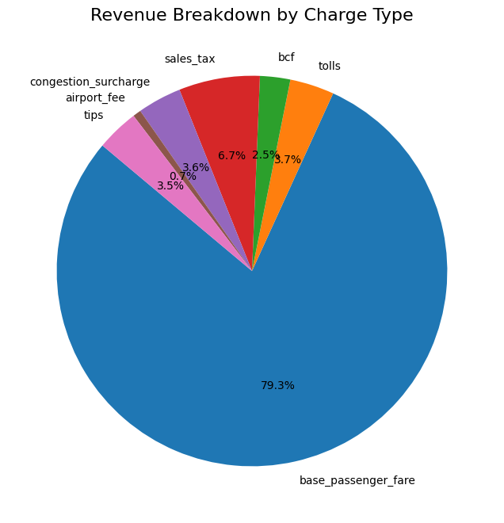

```python
charges = df[["base_passenger_fare","tolls","bcf","sales_tax",
				"congestion_surcharge","airport_fee","tips"]].sum()

  fig, ax = plt.subplots(figsize=(8,8))
  ax.pie(charges, labels=charges.index, autopct='%1.1f%%', startangle=140)
  ax.set_title("Revenue Breakdown by Charge Type", fontsize=16)
  plt.show()
```

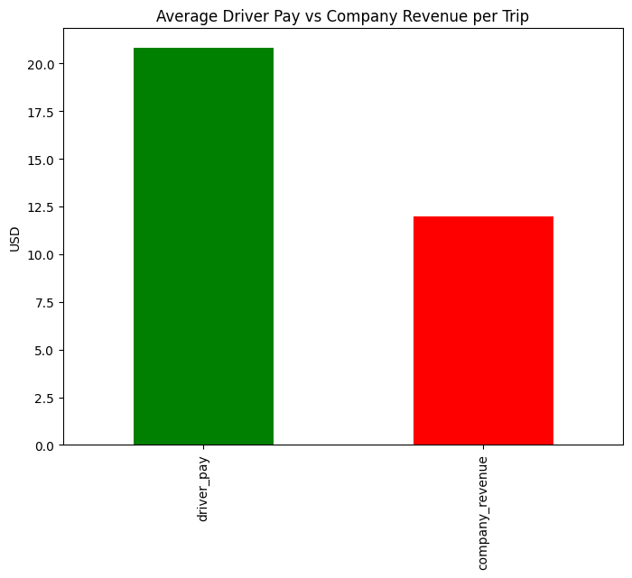

```python
df["total_fare"] = (df["base_passenger_fare"] + df["tolls"] +
					  df["bcf"] + df["sales_tax"] +
					  df["congestion_surcharge"] + df["airport_fee"] + df["tips"])

  df["company_revenue"] = df["total_fare"] - df["driver_pay"]

  compare = df[["driver_pay","company_revenue"]].mean()

  compare.plot(kind="bar", figsize=(8,6), color=["green","red"])
  plt.title("Average Driver Pay vs Company Revenue per Trip")
  plt.ylabel("USD")
  plt.show()
```

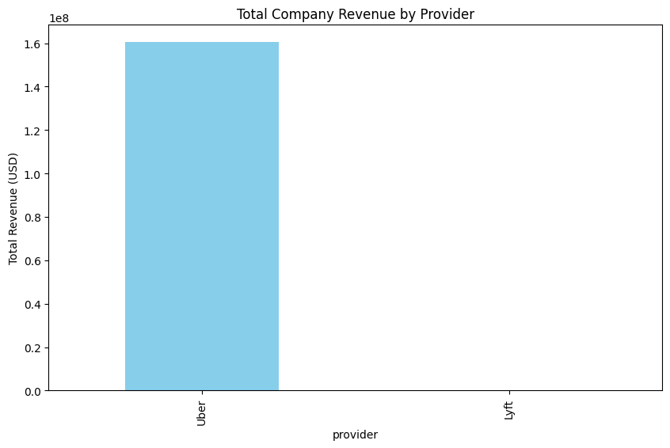

```python
provider_revenue = df.groupby("provider")["company_revenue"].sum().sort_values(ascending=False)

  provider_revenue.plot(kind="bar", figsize=(10,6), color="skyblue")
  plt.title("Total Company Revenue by Provider")
  plt.ylabel("Total Revenue (USD)")
  plt.show()
```

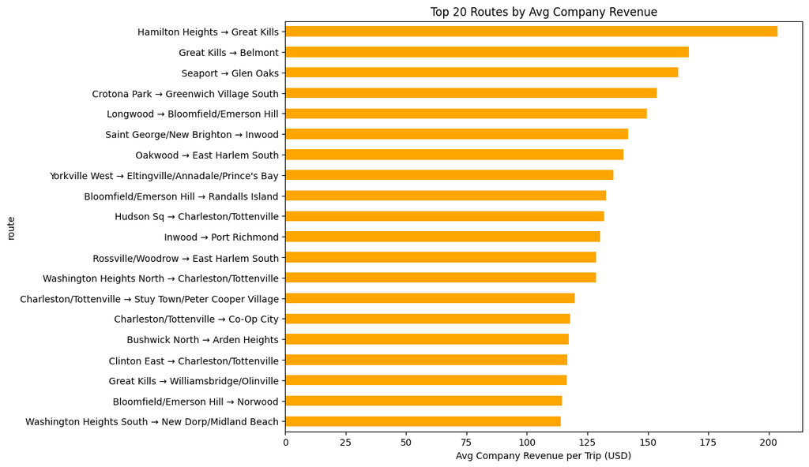

```python
top_routes_rev = df.groupby("route")["company_revenue"].mean().sort_values(ascending=False).head(20)

  top_routes_rev.plot(kind="barh", figsize=(10,8), color="orange")
  plt.title("Top 20 Routes by Avg Company Revenue")
  plt.xlabel("Avg Company Revenue per Trip (USD)")
  plt.gca().invert_yaxis()
  plt.show()
```

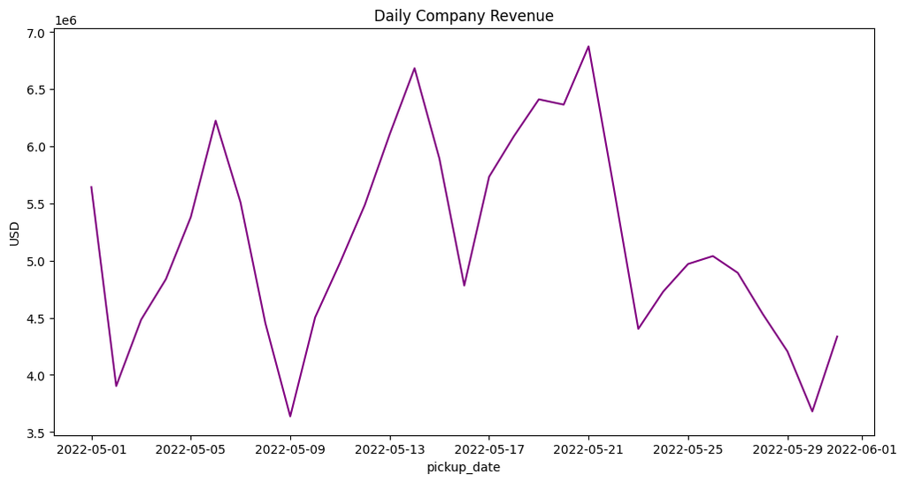

```python
df["pickup_date"] = df["pickup_datetime"].dt.date
  daily_rev = df.groupby("pickup_date")["company_revenue"].sum()

  daily_rev.plot(figsize=(12,6), title="Daily Company Revenue", color="purple")
  plt.ylabel("USD")
  plt.show()
```

```python
# Map phase: extract features
  df["pickup_hour"] = pd.to_datetime(df["pickup_datetime"]).dt.hour
  df["pickup_day"] = pd.to_datetime(df["pickup_datetime"]).dt.dayofweek  # 0=Mon,6=Sun

  # Reduce phase: aggregate demand
  df_reduced = df.groupby(["PULocationID", "pickup_day", "pickup_hour"]) \
				 .size().reset_index(name="trip_count")
```

[output not shown]

```python
from sklearn.linear_model import LinearRegression
  from sklearn.model_selection import train_test_split
  from sklearn.metrics import r2_score, mean_squared_error

  X = df_reduced[["pickup_day", "pickup_hour", "PULocationID"]]
  y = df_reduced["trip_count"]

  # Train/test split
  X_train, X_test, y_train, y_test = train_test_split(X, y, test_size=0.2, random_state=42)

  # Encode categorical (location)
  X_train = pd.get_dummies(X_train, columns=["PULocationID"])
  X_test = pd.get_dummies(X_test, columns=["PULocationID"]).reindex(columns=X_train.columns, fill_value=0)

  model = LinearRegression()
  model.fit(X_train, y_train)

  preds = model.predict(X_test)

  print("R2:", r2_score(y_test, preds))
```

```
  R2: 0.6713597485005395
```

```python
from sklearn.ensemble import RandomForestRegressor

  rf = RandomForestRegressor(n_estimators=100, random_state=42)
  rf.fit(X_train, y_train)
  preds_rf = rf.predict(X_test)

  print("R2:", r2_score(y_test, preds_rf))
  # print("RMSE:", mean_squared_error(y_test, preds_rf, squared=False))
```

```
  R2: 0.9427381187867035
```

```python
from xgboost import XGBRegressor

  xgb = XGBRegressor(n_estimators=200, learning_rate=0.1, random_state=42)
  xgb.fit(X_train, y_train)
  preds_xgb = xgb.predict(X_test)

  print("R2:", r2_score(y_test, preds_xgb))
  # print("RMSE:", mean_squared_error(y_test, preds_xgb, squared=False))
```

```
  R2: 0.820476233959198
```

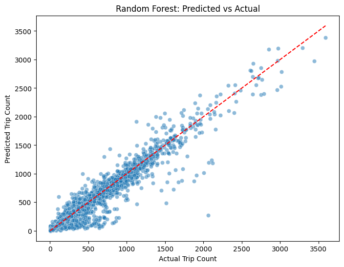

```python
import matplotlib.pyplot as plt
  import seaborn as sns

  plt.figure(figsize=(8,6))
  sns.scatterplot(x=y_test, y=preds_rf, alpha=0.5)
  plt.plot([y_test.min(), y_test.max()], [y_test.min(), y_test.max()], 'r--')  # ideal line
  plt.xlabel("Actual Trip Count")
  plt.ylabel("Predicted Trip Count")
  plt.title("Random Forest: Predicted vs Actual")
  plt.show()
```

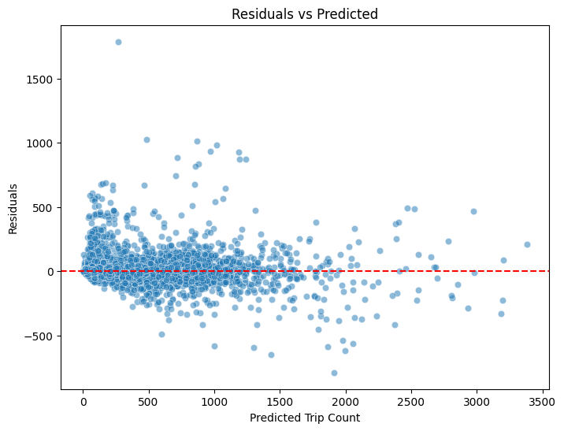

```python
residuals = y_test - preds_rf
  plt.figure(figsize=(8,6))
  sns.scatterplot(x=preds_rf, y=residuals, alpha=0.5)
  plt.axhline(0, color='red', linestyle='--')
  plt.xlabel("Predicted Trip Count")
  plt.ylabel("Residuals")
  plt.title("Residuals vs Predicted")
  plt.show()
```

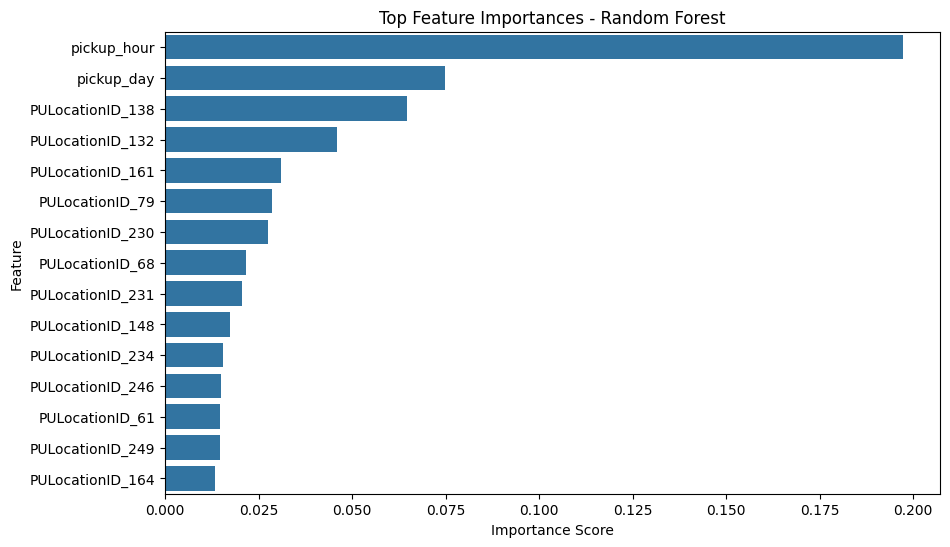

```python
import numpy as np

  importances = rf.feature_importances_
  feature_names = X_train.columns
  indices = np.argsort(importances)[::-1]

  plt.figure(figsize=(10,6))
  sns.barplot(x=importances[indices][:15], y=feature_names[indices][:15])
  plt.title("Top Feature Importances - Random Forest")
  plt.xlabel("Importance Score")
  plt.ylabel("Feature")
  plt.show()
```

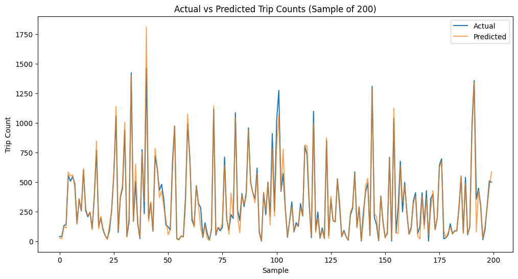

```python
import pandas as pd

  comparison = pd.DataFrame({"Actual": y_test, "Predicted": preds_rf})
  comparison = comparison.reset_index(drop=True)

  plt.figure(figsize=(12,6))
  plt.plot(comparison["Actual"].values[:200], label="Actual")
  plt.plot(comparison["Predicted"].values[:200], label="Predicted", alpha=0.7)
  plt.legend()
  plt.title("Actual vs Predicted Trip Counts (Sample of 200)")
  plt.xlabel("Sample")
  plt.ylabel("Trip Count")
  plt.show()
```